# Data Simulation for Archie

Ben Kesseler

June 7, 2016

# Order Execution Rate Sampling Frequency

Orders are executed based on when they come in, the complexity of the order, the system resources, and likely other factors as well. They vary somewhat in time to fully complete and begin at semi-random times, but we are more interested in the rate at which they are executed (finished).

## Initial Data Thoughts

Based on what I’ve learned from Archie, there are two time series to create, and then combine: time and orders executed.

### Time

The measurement of orders executed will happen stochastically, but certain aspects of the distribution of the timing are known.

- Mean time between measurements: 750ms
- Minimum time between measurements: 10ms
- Maximum time between measurements: 2s

```r
t <- rweibull(24*60*60, shape = 1.97, scale = 0.96) - 0.1 # location = -0.1
t[t <= 0.01] <- 0.01

t2 <- vector(mode = 'numeric', length = length(t) + 1)
for (i in 2:length(t2)) {
  t2[i] <- t2[i-1] + t[i-1]
}

# The range of possible values for the time between measurements
range(t)
```

```
## [1] 0.010000 3.161207
```

```r
# Statistics of t
describe(t)
```

```
## t
##       n missing  unique    Info    Mean     .05     .10     .25     .50
##   86400       0   85211       1  0.7505  0.1155  0.2059  0.4099  0.6962
##     .75     .90     .95
##  1.0312  1.3656  1.5788
##
## lowest : 0.01000 0.01000 0.01005 0.01026 0.01027
## highest: 3.02861 3.04160 3.07532 3.08573 3.16121
```

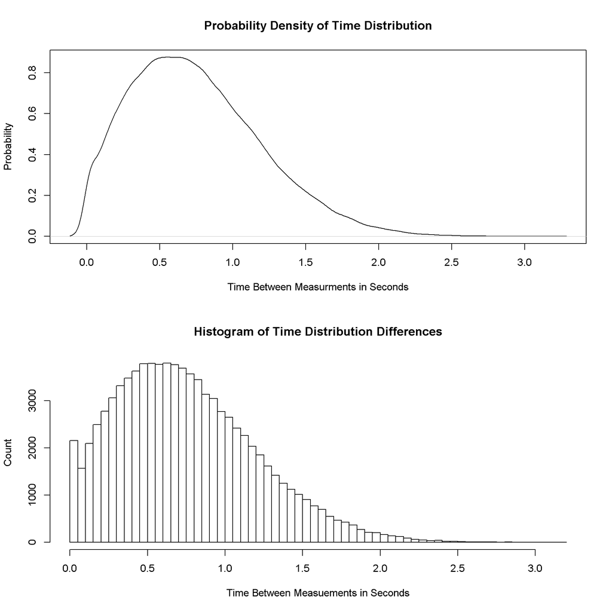

```r
# The distribution of t
par(mfrow=c(2,1))
plot(density(t),
     main = "Probability Density of Time Distribution",
     xlab = "Time Between Measurments in Seconds",
     ylab = "Probability"
     )
hist(t,
     breaks = 100,
     main = "Histogram of Time Distribution Differences",
     xlab = "Time Between Measuements in Seconds",
     ylab = "Count"
     )
```

### Orders Executed

A seemingly random number of orders will be executed within each time period. In reality, this number would be somewhat dependent on the time interval, with larger numbers of orders executed with larger time intervals, and smaller numbers of orders executed with smaller intervals.

I may attempt to create a correlation between length of time interval and the number of orders executed, but we’ll see.

The number of orders executed will happen stochastically, but certain aspects of the distribution of the number executed are known.

- Mean number of orders executed between measurements: 1200
- Minimum number of orders executed between measurements: 0
- Maximum number of orders executed between measurements: 2000

I will convert this to a Weibull distribution, with estimated parameters chosen to attempt to have the 99th percentile be near 2000, and the 1st percentile near 0. I am choosing to use a shifted Weibull (location isn’t 0), and actually allow negative values. I will replace all values less than 0 with 0, to simulate a slight bump in number of instances at 0. I will also take the floor of every value, because the number of orders executed cannot be a non-integer.

```r
o <- rweibull(24*60*60+1, shape = 7.483, scale = 3036) - 1650 # location = -1650
o[o <= 0] <- 0
o <- floor(o)

# The range of possible values for the number of orders executed each period
range(o)
```

```
## [1]    0 2699
```

```r
# Statistics of o
describe(o)
```

```
## o
##       n missing  unique    Info    Mean     .05     .10     .25     .50
##   86401       0    2337       1    1201     395     598     919    1239
##     .75     .90     .95
##    1518    1741    1865
##
## lowest :    0    1    2    3    4, highest: 2484 2513 2531 2565 2699
```

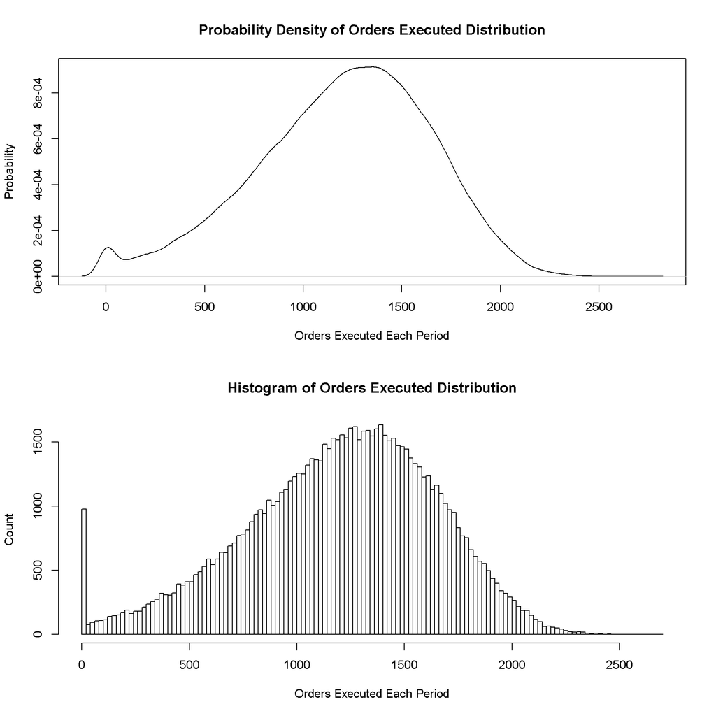

```r
# The distribution of o
par(mfrow=c(2,1))
plot(density(o),
     main = "Probability Density of Orders Executed Distribution",
     xlab = "Orders Executed Each Period",
     ylab = "Probability"
     )
hist(o,
     breaks = 100,
     main = "Histogram of Orders Executed Distribution",
     xlab = "Orders Executed Each Period",
     ylab = "Count"
     )
```

Now I will create the final raw dataset for analysis in Tableau.

```r
tableau <- as.data.frame(cbind(t2, o))
colnames(tableau) <- c("time", "orders executed")
write.csv(tableau, "Archie_Tableau_Data.csv", row.names = FALSE)
```

```r
# I take the sum of orders executed less than the current time, and subtract
# the sum for the previous time value, determining the number of orders executed
# in that time interval.

create_meas <- function(f_meas) {
  current_meas <- f_meas
  time_intervals <- seq(0, ceiling(max(t2)), f_meas)
  temp_meas <- time_intervals
  temp_orders <- time_intervals
  temp_meas[1] <- sum(tableau$`orders executed`[tableau$time < current_meas])
  temp_orders[1] <- sum(tableau$`orders executed`[tableau$time < current_meas])
  for (i in 2:length(temp_meas)) {
    temp_meas[i] <- sum(tableau$`orders executed`[tableau$time < current_meas])
    temp_orders[i] <- temp_meas[i] - temp_meas[i-1]
    current_meas <- current_meas + f_meas
  }
  temp_orders <- temp_orders / f_meas
  measurement_interval <- rep(f_meas, length(temp_orders))
  cumave <- cumsum(temp_orders) / seq_along(temp_orders)
  temp_meas_out <- as.data.frame(cbind(measurement_interval,
                                       time_intervals,
                                       temp_orders,
                                       cumave))
  temp_meas_out
}

measure_list <- seq(0.250, 5.000, 0.250)

ptm <- proc.time()
averages <- create_meas(measure_list[1])
elapsed_time_temp <- proc.time() - ptm
elapsed_time <- elapsed_time_temp[3]
message <- paste(measure_list[1],
                 "s interval completed in ",
                 format(elapsed_time_temp[3]),
                 "s. Total elapsed time: ",
                 format(elapsed_time), "s.")
print(message)
```

```
## [1] "0.25 s interval completed in  367.63 s. Total elapsed time:  367.63 s."
```

```r
for (i in 2:length(measure_list)) {
  ptm <- proc.time()
  meas_x <- create_meas(measure_list[i])
  averages <- rbind(averages, meas_x)
  elapsed_time_temp <- proc.time() - ptm
  elapsed_time <- elapsed_time + elapsed_time_temp[3]
  message <- paste(measure_list[i],
                   "s interval completed in ",
                   format(elapsed_time_temp[3]),
                   "s. Total elapsed time: ",
                   format(elapsed_time), "s.")
  print(message)
}
```

```
## [1] "0.5 s interval completed in  171.76 s. Total elapsed time:  539.39 s."
## [1] "0.75 s interval completed in  108.38 s. Total elapsed time:  647.77 s."
## [1] "1 s interval completed in  78.86 s. Total elapsed time:  726.63 s."
## [1] "1.25 s interval completed in  62.33 s. Total elapsed time:  788.96 s."
## [1] "1.5 s interval completed in  52.61 s. Total elapsed time:  841.57 s."
## [1] "1.75 s interval completed in  46.23 s. Total elapsed time:  887.8 s."
## [1] "2 s interval completed in  39.09 s. Total elapsed time:  926.89 s."
## [1] "2.25 s interval completed in  34.35 s. Total elapsed time:  961.24 s."
## [1] "2.5 s interval completed in  31.87 s. Total elapsed time:  993.11 s."
## [1] "2.75 s interval completed in  28.27 s. Total elapsed time:  1021.38 s."
## [1] "3 s interval completed in  26.12 s. Total elapsed time:  1047.5 s."
## [1] "3.25 s interval completed in  23.39 s. Total elapsed time:  1070.89 s."
## [1] "3.5 s interval completed in  21.69 s. Total elapsed time:  1092.58 s."
## [1] "3.75 s interval completed in  20.88 s. Total elapsed time:  1113.46 s."
## [1] "4 s interval completed in  21.03 s. Total elapsed time:  1134.49 s."
## [1] "4.25 s interval completed in  20.01 s. Total elapsed time:  1154.5 s."
## [1] "4.5 s interval completed in  17.53 s. Total elapsed time:  1172.03 s."
## [1] "4.75 s interval completed in  16.07 s. Total elapsed time:  1188.1 s."
## [1] "5 s interval completed in  15.29 s. Total elapsed time:  1203.39 s."
```

```r
colnames(averages) <- c("measurement interval",
                        "time",
                        "orders executed per second",
                        "cumulative average")
write.csv(averages, "Archie_Tableau_Data_Average_Rates.csv")
```

# Additional Resources

- [Github Repository](https://github.com/bkkesseler/datasimulationforarchie)

# Session Information

- Toshiba Chromeboook 2 (2015)
- 1.70 GHz Intel Celeron 3215U
- 4GB RAM
- RStudio Version 0.99.893